# Linear Model Selection and Regularization (ISL 6)

Biostat 212A

Author

Dr. Jin Zhou @ UCLA

Published

February 7, 2026

Credit: This note heavily uses material from the books [*An Introduction to Statistical Learning: with Applications in R*](https://www.statlearning.com/) (ISL2) and [*Elements of Statistical Learning: Data Mining, Inference, and Prediction*](https://hastie.su.domains/ElemStatLearn/) (ESL2).

Display system information for reproducibility.

**R**

**Python**

```python
import IPython
print(IPython.sys_info())
```

```
{'commit_hash': '5ed988a91',
 'commit_source': 'installation',
 'default_encoding': 'utf-8',
 'ipython_path': '/Users/jinjinzhou/.virtualenvs/r-tensorflow/lib/python3.10/site-packages/IPython',
 'ipython_version': '8.33.0',
 'os_name': 'posix',
 'platform': 'macOS-15.7.3-arm64-arm-64bit',
 'sys_executable': '/Users/jinjinzhou/.virtualenvs/r-tensorflow/bin/python',
 'sys_platform': 'darwin',
 'sys_version': '3.10.16 (main, Mar  3 2025, 20:01:33) [Clang 16.0.0 '
                '(clang-1600.0.26.6)]'}
```

## 1 Overview

- In linear regression (ISL 3), we assume
  $$Y = \beta_0 + \beta_1 X_1 + \cdots + \beta_p X_p + \epsilon.$$
- In this lecture, we discuss some ways in which the simple linear model can be improved, by replacing ordinary least squares fitting with some alternative fitting procedures.
- Why consider alternatives to least squares?
  - **Prediction accuracy**: especially when $p > n$, to control the variance.
  - **Model interpretability**: By removing irrelevant features - that is, by setting the corresponding coefficient estimates to zero - we can obtain a model that is more easily interpreted. We will present some approaches for automatically performing **feature selection**.
- Three classes of methods:
  - **Subset selection**: We identify a subset of the $p$ predictors that we believe to be related to the response. We then fit a model using least squares on the reduced set of variables.
  - **Shrinkage**: We fit a model involving all $p$ predictors, but the estimated coefficients are shrunken towards zero relative to the least squares estimates. This shrinkage (also known as **regularization**) has the effect of reducing variance and can also perform variable selection.
  - **Dimension reduction**: We project the $p$ predictors into an $M$-dimensional subspace, where $M < p$. This is achieved by computing $M$ different **linear combinations**, or **projections**, of the variables. Then these $M$ projections are used as predictors to fit a linear regression model by least squares.

## 2 `Credit` data set

We will use the `Credit` data set as a running example. A documentation of this data set is at [here](https://www.rdocumentation.org/packages/ISLR2/versions/1.3-2/topics/Credit).

**R**

```r
library(GGally) # ggpairs function
library(ISLR2)
library(tidyverse)

# Cast to tibble
Credit <- as_tibble(Credit) %>% print(width = Inf)
```

```
# A tibble: 400 × 11
   Income Limit Rating Cards   Age Education Own   Student Married Region
    <dbl> <dbl>  <dbl> <dbl> <dbl>     <dbl> <fct> <fct>   <fct>   <fct>
 1   14.9  3606    283     2    34        11 No    No      Yes     South
 2  106.   6645    483     3    82        15 Yes   Yes     Yes     West
 3  105.   7075    514     4    71        11 No    No      No      West
 4  149.   9504    681     3    36        11 Yes   No      No      West
 5   55.9  4897    357     2    68        16 No    No      Yes     South
 6   80.2  8047    569     4    77        10 No    No      No      South
 7   21.0  3388    259     2    37        12 Yes   No      No      East
 8   71.4  7114    512     2    87         9 No    No      No      West
 9   15.1  3300    266     5    66        13 Yes   No      No      South
10   71.1  6819    491     3    41        19 Yes   Yes     Yes     East
   Balance
     <dbl>
 1     333
 2     903
 3     580
 4     964
 5     331
 6    1151
 7     203
 8     872
 9     279
10    1350
# ℹ 390 more rows
```

```r
# Numerical summary
summary(Credit)
```

```
     Income           Limit           Rating          Cards
 Min.   : 10.35   Min.   :  855   Min.   : 93.0   Min.   :1.000
 1st Qu.: 21.01   1st Qu.: 3088   1st Qu.:247.2   1st Qu.:2.000
 Median : 33.12   Median : 4622   Median :344.0   Median :3.000
 Mean   : 45.22   Mean   : 4736   Mean   :354.9   Mean   :2.958
 3rd Qu.: 57.47   3rd Qu.: 5873   3rd Qu.:437.2   3rd Qu.:4.000
 Max.   :186.63   Max.   :13913   Max.   :982.0   Max.   :9.000
      Age          Education      Own      Student   Married     Region
 Min.   :23.00   Min.   : 5.00   No :193   No :360   No :155   East : 99
 1st Qu.:41.75   1st Qu.:11.00   Yes:207   Yes: 40   Yes:245   South:199
 Median :56.00   Median :14.00                                 West :102
 Mean   :55.67   Mean   :13.45
 3rd Qu.:70.00   3rd Qu.:16.00
 Max.   :98.00   Max.   :20.00
    Balance
 Min.   :   0.00
 1st Qu.:  68.75
 Median : 459.50
 Mean   : 520.01
 3rd Qu.: 863.00
 Max.   :1999.00
```

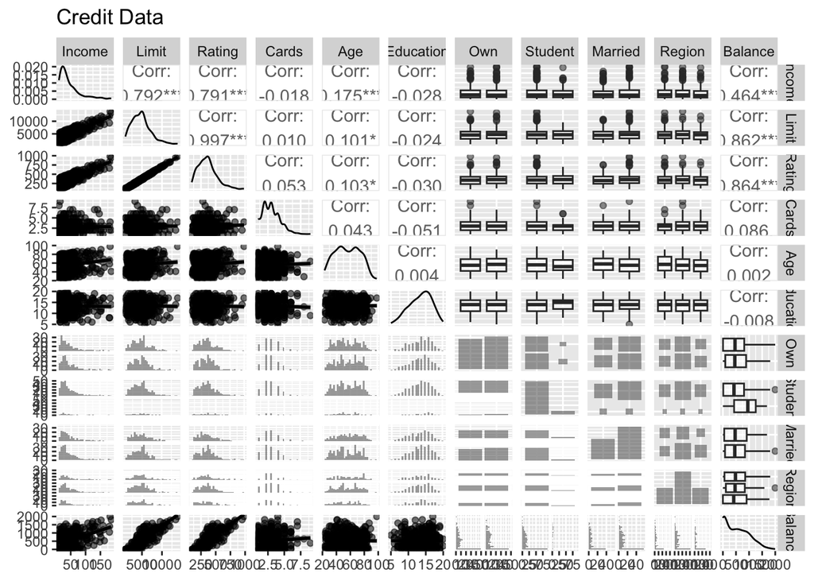

```r
# Graphical summary
ggpairs(
  data = Credit,
  mapping = aes(alpha = 0.25),
  lower = list(continuous = "smooth")
  ) +
  labs(title = "Credit Data")
```

**Python**

```python
# Load the pandas library
import pandas as pd
# Load numpy for array manipulation
import numpy as np
# Load seaborn plotting library
import seaborn as sns
import matplotlib.pyplot as plt

# Set font sizes in plots
sns.set(font_scale = 2)
# Display all columns
pd.set_option('display.max_columns', None)

# Import Advertising data
Credit = pd.read_csv("../data/Credit.csv")
Credit
```

```
      Income  Limit  Rating  Cards  Age  Education  Own Student Married  \
0     14.891   3606     283      2   34         11   No      No     Yes
1    106.025   6645     483      3   82         15  Yes     Yes     Yes
2    104.593   7075     514      4   71         11   No      No      No
3    148.924   9504     681      3   36         11  Yes      No      No
4     55.882   4897     357      2   68         16   No      No     Yes
..       ...    ...     ...    ...  ...        ...  ...     ...     ...
395   12.096   4100     307      3   32         13   No      No     Yes
396   13.364   3838     296      5   65         17   No      No      No
397   57.872   4171     321      5   67         12  Yes      No     Yes
398   37.728   2525     192      1   44         13   No      No     Yes
399   18.701   5524     415      5   64          7  Yes      No      No

    Region  Balance
0    South      333
1     West      903
2     West      580
3     West      964
4    South      331
..     ...      ...
395  South      560
396   East      480
397  South      138
398  South        0
399   West      966

[400 rows x 11 columns]
```

```python
# Numerical summary
Credit.describe()
```

```
           Income         Limit      Rating       Cards         Age  \
count  400.000000    400.000000  400.000000  400.000000  400.000000
mean    45.218885   4735.600000  354.940000    2.957500   55.667500
std     35.244273   2308.198848  154.724143    1.371275   17.249807
min     10.354000    855.000000   93.000000    1.000000   23.000000
25%     21.007250   3088.000000  247.250000    2.000000   41.750000
50%     33.115500   4622.500000  344.000000    3.000000   56.000000
75%     57.470750   5872.750000  437.250000    4.000000   70.000000
max    186.634000  13913.000000  982.000000    9.000000   98.000000

        Education      Balance
count  400.000000   400.000000
mean    13.450000   520.015000
std      3.125207   459.758877
min      5.000000     0.000000
25%     11.000000    68.750000
50%     14.000000   459.500000
75%     16.000000   863.000000
max     20.000000  1999.000000
```

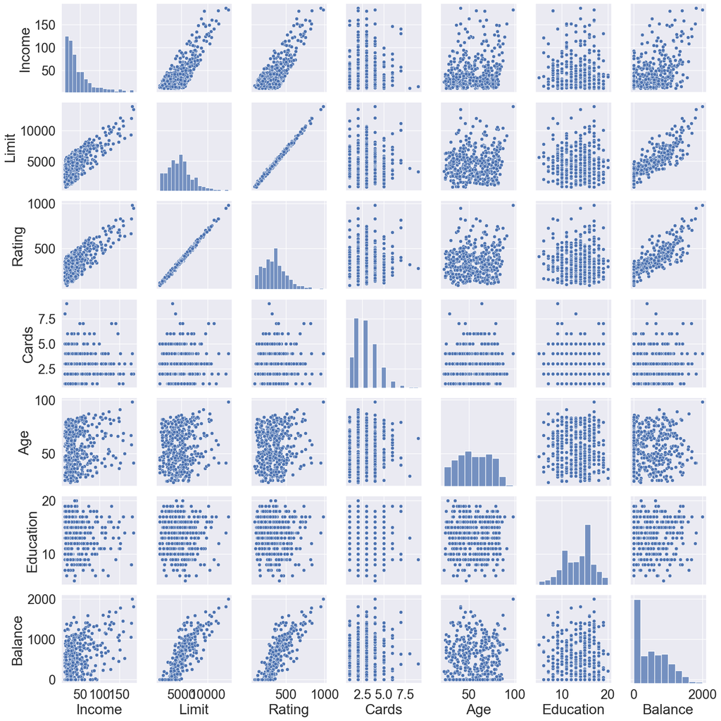

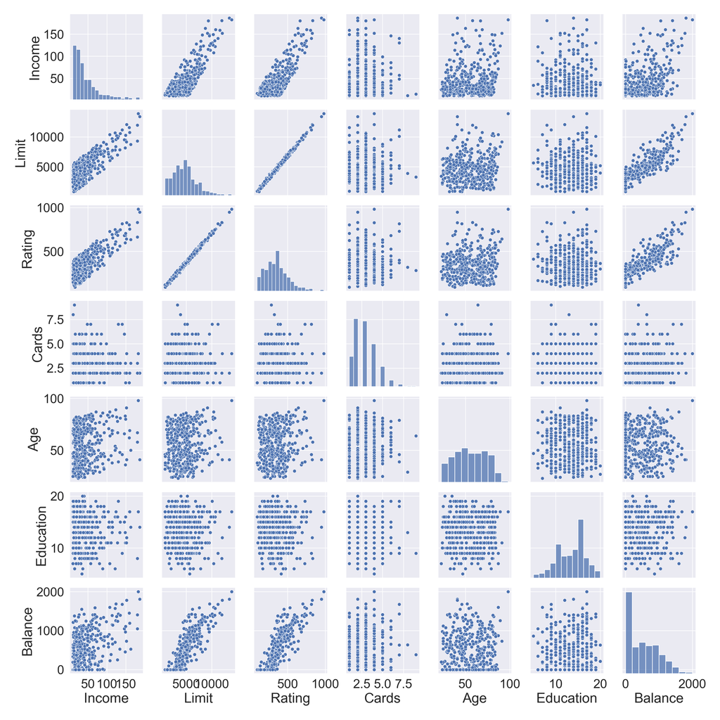

```python
# Graphical summary
sns.pairplot(data = Credit)
```

## 3 Subset selection

### 3.1 Best subset selection

- **Best subset selection** algorithm:
  1. Let $\mathcal{M}_0$ be the **null model**, which contains no predictors besides the intercept. This model simply predicts the sample mean for each observation.
  2. For $k = 1,2, \ldots, p$:
     1. Fit all $\binom{p}{k}$ models that contain exactly $k$ predictors.
     2. Pick the best among these $\binom{p}{k}$ models, and call it $\mathcal{M}_k$. Here **best** is defined as having the smallest RSS, or equivalently largest $R^2$.
  3. Select a single best model from among $\mathcal{M}_0, \mathcal{M}_1, \ldots, \mathcal{M}_p$ using cross-validated prediction error, $C_p$ (AIC), BIC, or adjusted $R^2$.
- Best subset selection for the `Credit` data.

**R**

```r
library(leaps)

# Fit best subset regression
bst_mod <- regsubsets(
  Balance ~ .,
  data = Credit,
  method = "exhaustive",
  nvmax = 11
  ) %>% summary()
bst_mod
```

```
Subset selection object
Call: regsubsets.formula(Balance ~ ., data = Credit, method = "exhaustive",
    nvmax = 11)
11 Variables  (and intercept)
            Forced in Forced out
Income          FALSE      FALSE
Limit           FALSE      FALSE
Rating          FALSE      FALSE
Cards           FALSE      FALSE
Age             FALSE      FALSE
Education       FALSE      FALSE
OwnYes          FALSE      FALSE
StudentYes      FALSE      FALSE
MarriedYes      FALSE      FALSE
RegionSouth     FALSE      FALSE
RegionWest      FALSE      FALSE
1 subsets of each size up to 11
Selection Algorithm: exhaustive
          Income Limit Rating Cards Age Education OwnYes StudentYes MarriedYes
1  ( 1 )  " "    " "   "*"    " "   " " " "       " "    " "        " "
2  ( 1 )  "*"    " "   "*"    " "   " " " "       " "    " "        " "
3  ( 1 )  "*"    " "   "*"    " "   " " " "       " "    "*"        " "
4  ( 1 )  "*"    "*"   " "    "*"   " " " "       " "    "*"        " "
5  ( 1 )  "*"    "*"   "*"    "*"   " " " "       " "    "*"        " "
6  ( 1 )  "*"    "*"   "*"    "*"   "*" " "       " "    "*"        " "
7  ( 1 )  "*"    "*"   "*"    "*"   "*" " "       "*"    "*"        " "
8  ( 1 )  "*"    "*"   "*"    "*"   "*" " "       "*"    "*"        " "
9  ( 1 )  "*"    "*"   "*"    "*"   "*" " "       "*"    "*"        "*"
10  ( 1 ) "*"    "*"   "*"    "*"   "*" " "       "*"    "*"        "*"
11  ( 1 ) "*"    "*"   "*"    "*"   "*" "*"       "*"    "*"        "*"
          RegionSouth RegionWest
1  ( 1 )  " "         " "
2  ( 1 )  " "         " "
3  ( 1 )  " "         " "
4  ( 1 )  " "         " "
5  ( 1 )  " "         " "
6  ( 1 )  " "         " "
7  ( 1 )  " "         " "
8  ( 1 )  " "         "*"
9  ( 1 )  " "         "*"
10  ( 1 ) "*"         "*"
11  ( 1 ) "*"         "*"
```

```r
# Display selection criteria
bst_result <- tibble(
  K = 1:11,
  R2 = bst_mod$rsq,
  adjR2 = bst_mod$adjr2,
  BIC = bst_mod$bic,
  CP = bst_mod$cp
) %>% print(width = Inf)
```

```
# A tibble: 11 × 5
       K    R2 adjR2    BIC      CP
   <int> <dbl> <dbl>  <dbl>   <dbl>
 1     1 0.746 0.745  -536. 1800.
 2     2 0.875 0.874  -814.  685.
 3     3 0.950 0.949 -1173.   41.1
 4     4 0.954 0.953 -1198.   11.1
 5     5 0.954 0.954 -1197.    8.13
 6     6 0.955 0.954 -1196.    5.57
 7     7 0.955 0.954 -1191.    6.46
 8     8 0.955 0.954 -1186.    7.85
 9     9 0.955 0.954 -1180.    9.19
10    10 0.955 0.954 -1175.   10.5
11    11 0.955 0.954 -1169.   12.0
```

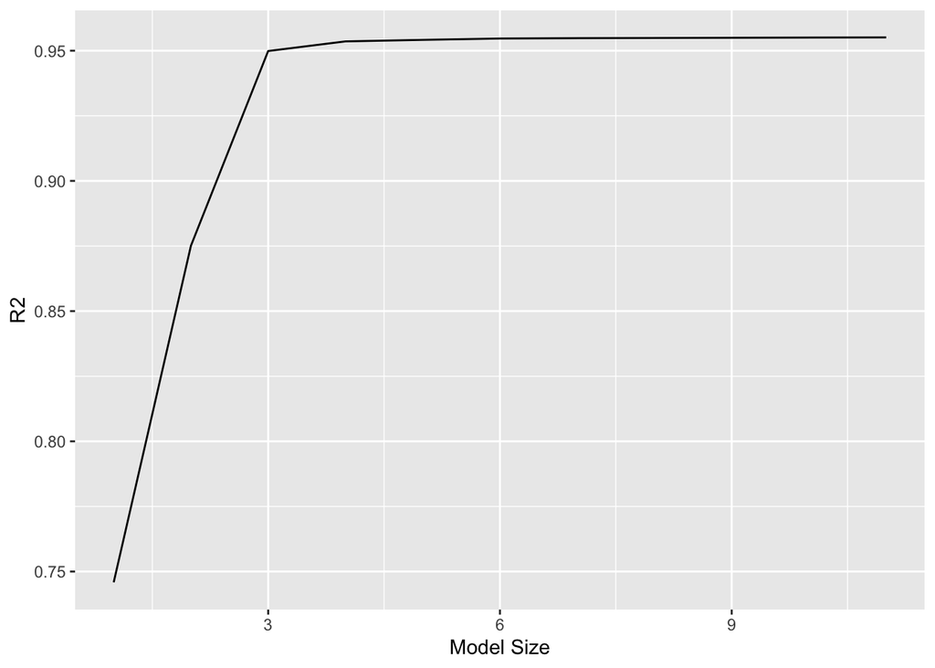

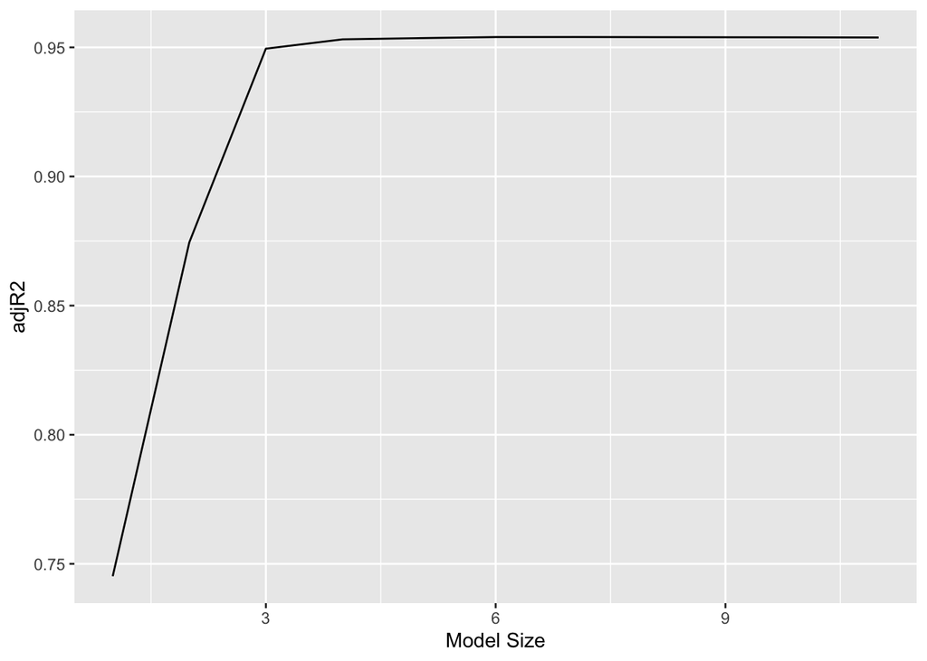

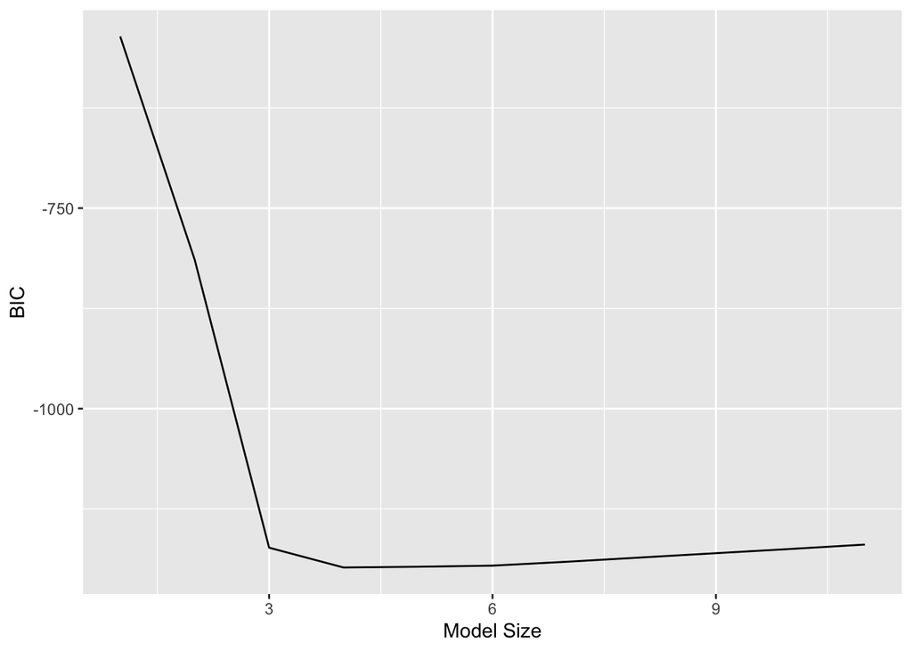

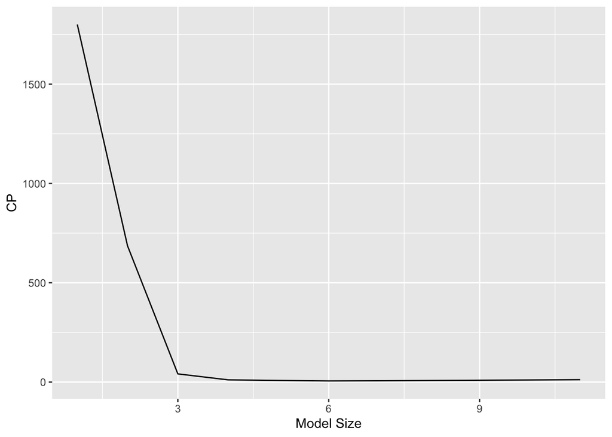

```r
# Visualize
cols <- names(bst_result)
for (j in 2:5) {
  (bst_result %>%
  select(K, !!sym(cols[j])) %>%
  ggplot() +
    geom_line(mapping = aes(x = K, y = !!sym(cols[j]))) +
    labs(x = 'Model Size', y = cols[j])) %>%
  print()
}
```

- Adjusted $R^2$ chooses the best model of size 7: `income`, `limit`, `rating`, `cards`, `age`, `student` and `own`.

  $C_p$ (and AIC) chooses the best model of size 6: `income`, `limit`, `rating`, `cards`, `age` and `student`.

  BIC chooses the best model of size 4: `income`, `limit`, `cards` and `student`.
- Although we have presented best subset selection here for least squares regression, the same ideas apply to other types of models, such as **logistic regression** (discussed in Chapter 4). The **deviance** (negative two times the maximized log-likelihood) plays the role of RSS for a broader class of models.
- For computational reasons, best subset selection cannot be applied with very large $p$. When $p = 20$, there are $2^p = 1,048,576$ models!
- Stepwise methods, which explore a far more restricted set of models, are attractive alternatives to best subset selection.

### 3.2 Forward stepwise selection

- Forward stepwise selection begins with a model containing no predictors, and then adds predictors to the model, one-at-a-time, until all of the predictors are in the model.
- In particular, at each step the variable that gives the greatest additional improvement to the fit is added to the model.
- - **Forward stepwise selection** algorithm:
    1. Let $\mathcal{M}_0$ be the **null model**, which contains no predictors besides the intercept.
    2. For $k = 0,1,\ldots, p-1$:
       1. Consider all $p-k$ models that augment the predictors in $\mathcal{M}_k$ with one additional predictor.
       2. Pick the best among these $p-k$ models, and call it $\mathcal{M}_{k+1}$. Here **best** is defined as having the smallest RSS, or equivalently largest $R^2$.
    3. Select a single best model from among $\mathcal{M}_0, \mathcal{M}_1, \ldots, \mathcal{M}_p$ using cross-validated prediction error, $C_p$ (AIC), BIC, or adjusted $R^2$.
- Forward stepwise selection for the `Credit` data.

```r
library(leaps)

# Fit best subset regression
fs_mod <- regsubsets(
  Balance ~ .,
  data = Credit,
  method = "forward",
  nvmax = 11
  ) %>% summary()
fs_mod
```

```
Subset selection object
Call: regsubsets.formula(Balance ~ ., data = Credit, method = "forward",
    nvmax = 11)
11 Variables  (and intercept)
            Forced in Forced out
Income          FALSE      FALSE
Limit           FALSE      FALSE
Rating          FALSE      FALSE
Cards           FALSE      FALSE
Age             FALSE      FALSE
Education       FALSE      FALSE
OwnYes          FALSE      FALSE
StudentYes      FALSE      FALSE
MarriedYes      FALSE      FALSE
RegionSouth     FALSE      FALSE
RegionWest      FALSE      FALSE
1 subsets of each size up to 11
Selection Algorithm: forward
          Income Limit Rating Cards Age Education OwnYes StudentYes MarriedYes
1  ( 1 )  " "    " "   "*"    " "   " " " "       " "    " "        " "
2  ( 1 )  "*"    " "   "*"    " "   " " " "       " "    " "        " "
3  ( 1 )  "*"    " "   "*"    " "   " " " "       " "    "*"        " "
4  ( 1 )  "*"    "*"   "*"    " "   " " " "       " "    "*"        " "
5  ( 1 )  "*"    "*"   "*"    "*"   " " " "       " "    "*"        " "
6  ( 1 )  "*"    "*"   "*"    "*"   "*" " "       " "    "*"        " "
7  ( 1 )  "*"    "*"   "*"    "*"   "*" " "       "*"    "*"        " "
8  ( 1 )  "*"    "*"   "*"    "*"   "*" " "       "*"    "*"        " "
9  ( 1 )  "*"    "*"   "*"    "*"   "*" " "       "*"    "*"        "*"
10  ( 1 ) "*"    "*"   "*"    "*"   "*" " "       "*"    "*"        "*"
11  ( 1 ) "*"    "*"   "*"    "*"   "*" "*"       "*"    "*"        "*"
          RegionSouth RegionWest
1  ( 1 )  " "         " "
2  ( 1 )  " "         " "
3  ( 1 )  " "         " "
4  ( 1 )  " "         " "
5  ( 1 )  " "         " "
6  ( 1 )  " "         " "
7  ( 1 )  " "         " "
8  ( 1 )  " "         "*"
9  ( 1 )  " "         "*"
10  ( 1 ) "*"         "*"
11  ( 1 ) "*"         "*"
```

```r
# Display selection criteria
tibble(
  K = 1:11,
  R2 = fs_mod$rsq,
  adjR2 = fs_mod$adjr2,
  BIC = fs_mod$bic,
  CP = fs_mod$cp
) %>% print(width = Inf)
```

```
# A tibble: 11 × 5
       K    R2 adjR2    BIC      CP
   <int> <dbl> <dbl>  <dbl>   <dbl>
 1     1 0.746 0.745  -536. 1800.
 2     2 0.875 0.874  -814.  685.
 3     3 0.950 0.949 -1173.   41.1
 4     4 0.952 0.952 -1186.   23.2
 5     5 0.954 0.954 -1197.    8.13
 6     6 0.955 0.954 -1196.    5.57
 7     7 0.955 0.954 -1191.    6.46
 8     8 0.955 0.954 -1186.    7.85
 9     9 0.955 0.954 -1180.    9.19
10    10 0.955 0.954 -1175.   10.5
11    11 0.955 0.954 -1169.   12.0
```

- Best subset and forward stepwise selections start to differ from $\mathcal{M}_4$.
- Computational advantage of forward stepwise selection over best subset selection is clear.
- It is not guaranteed to find the best possible model out of all $2^p$ models containing subsets of the $p$ predictors.

### 3.3 Backward stepwise regression

- **Backward stepwise selection** algorithm:
  1. Let $\mathcal{M}_0$ be the **full model**, which contains all $p$ predictors.
  2. For $k = p,p-1,\ldots, 1$:
     1. Consider all $k$ models that contain all but one of the predictors in $\mathcal{M}_k$, for a total of $k-1$ predictors.
     2. Pick the best among these $k$ models, and call it $\mathcal{M}_{k}$. Here **best** is defined as having the smallest RSS, or equivalently largest $R^2$.
  3. Select a single best model from among $\mathcal{M}_0, \mathcal{M}_1, \ldots, \mathcal{M}_p$ using cross-validated prediction error, $C_p$ (AIC), BIC, or adjusted $R^2$.

```r
library(leaps)

# Fit best subset regression
bs_mod <- regsubsets(
  Balance ~ .,
  data = Credit,
  method = "backward",
  nvmax = 11
  ) %>% summary()
bs_mod
```

```
Subset selection object
Call: regsubsets.formula(Balance ~ ., data = Credit, method = "backward",
    nvmax = 11)
11 Variables  (and intercept)
            Forced in Forced out
Income          FALSE      FALSE
Limit           FALSE      FALSE
Rating          FALSE      FALSE
Cards           FALSE      FALSE
Age             FALSE      FALSE
Education       FALSE      FALSE
OwnYes          FALSE      FALSE
StudentYes      FALSE      FALSE
MarriedYes      FALSE      FALSE
RegionSouth     FALSE      FALSE
RegionWest      FALSE      FALSE
1 subsets of each size up to 11
Selection Algorithm: backward
          Income Limit Rating Cards Age Education OwnYes StudentYes MarriedYes
1  ( 1 )  " "    "*"   " "    " "   " " " "       " "    " "        " "
2  ( 1 )  "*"    "*"   " "    " "   " " " "       " "    " "        " "
3  ( 1 )  "*"    "*"   " "    " "   " " " "       " "    "*"        " "
4  ( 1 )  "*"    "*"   " "    "*"   " " " "       " "    "*"        " "
5  ( 1 )  "*"    "*"   "*"    "*"   " " " "       " "    "*"        " "
6  ( 1 )  "*"    "*"   "*"    "*"   "*" " "       " "    "*"        " "
7  ( 1 )  "*"    "*"   "*"    "*"   "*" " "       "*"    "*"        " "
8  ( 1 )  "*"    "*"   "*"    "*"   "*" " "       "*"    "*"        " "
9  ( 1 )  "*"    "*"   "*"    "*"   "*" " "       "*"    "*"        "*"
10  ( 1 ) "*"    "*"   "*"    "*"   "*" " "       "*"    "*"        "*"
11  ( 1 ) "*"    "*"   "*"    "*"   "*" "*"       "*"    "*"        "*"
          RegionSouth RegionWest
1  ( 1 )  " "         " "
2  ( 1 )  " "         " "
3  ( 1 )  " "         " "
4  ( 1 )  " "         " "
5  ( 1 )  " "         " "
6  ( 1 )  " "         " "
7  ( 1 )  " "         " "
8  ( 1 )  " "         "*"
9  ( 1 )  " "         "*"
10  ( 1 ) "*"         "*"
11  ( 1 ) "*"         "*"
```

```r
# Display selection criteria
tibble(
  K = 1:11,
  R2 = bs_mod$rsq,
  adjR2 = bs_mod$adjr2,
  BIC = bs_mod$bic,
  CP = bs_mod$cp
) %>% print(width = Inf)
```

```
# A tibble: 11 × 5
       K    R2 adjR2    BIC      CP
   <int> <dbl> <dbl>  <dbl>   <dbl>
 1     1 0.743 0.742  -531. 1829.
 2     2 0.871 0.870  -802.  720.
 3     3 0.949 0.948 -1165.   50.3
 4     4 0.954 0.953 -1198.   11.1
 5     5 0.954 0.954 -1197.    8.13
 6     6 0.955 0.954 -1196.    5.57
 7     7 0.955 0.954 -1191.    6.46
 8     8 0.955 0.954 -1186.    7.85
 9     9 0.955 0.954 -1180.    9.19
10    10 0.955 0.954 -1175.   10.5
11    11 0.955 0.954 -1169.   12.0
```

- For the `Credit` data, backward stepwise selection matches the best subset selection up to $\mathcal{M}_4$ (backwards).
- Like forward stepwise selection, the backward selection approach searches through only $1 + p(p+1)/2$ models, and so can be applied in settings where $p$ is too large to apply best subset selection. When $p=20$, only $1 + p(p+1)/2 = 211$ models.
- Like forward stepwise selection, backward stepwise selection is not guaranteed to yield the best model containing a subset of the $p$ predictors.
- Backward selection requires that the number of samples $n$ is larger than the number of variables $p$ (so that the full model can be fit). In contrast, forward stepwise can be used even when $n < p$, and so is the only viable subset method when $p$ is very large.

## 4 Criteria for model selection

- The model containing all of the predictors will always have the smallest RSS and the largest $R^2$, since these quantities are related to the **training error**.
- We wish to choose a model with low **test error**, not a model with low training error. Recall that training error is usually a poor estimate of test error.
- Therefore, RSS and $R^2$ are not suitable for selecting the best model among a collection of models with different numbers of predictors.
- Two approaches for estimating test error:
  - We can indirectly estimate test error by making an adjustment to the training error to account for the bias due to overfitting.
  - We can directly estimate the test error, using either a validation set approach or a cross-validation approach, as discussed in previous lecture.

### 4.1 Indirect approaches: $C_p$, AIC, BIC, adjusted $R^2$

- Mallow’s $C_p$:
  $$C_p = \frac{1}{n} (\text{RSS} + 2d \hat{\sigma}^2),$$
  where $d$ is the total number of parameters used and $\hat{\sigma}^2$ is an estimate of the error variance $\text{Var}(\epsilon)$. Smaller $C_p$ means better model.
- The AIC criterion:
  $$\text{AIC} = - 2 \log L + 2d,$$
  where $L$ is the maximized value of the likelihood function for the estimated model. Smaller AIC means better model.

  In the case of the linear model with Gaussian errors, maximum likelihood and least squares are the same thing, and $C_p$ and AIC are equivalent.
- BIC:
  $$\text{BIC} = \frac{1}{n}(\text{RSS} + \log(n) d \hat{\sigma}^2).$$
  Smaller BIC means better model.

  Since $\log n > 2$ for any $n > 7$, the BIC statistic generally places a heavier penalty on models with many variables, and hence results in the selection of smaller models than $C_p$.
- Adjusted $R^2$:
  $$\text{Adjusted } R^2 = 1 - \frac{\text{RSS}/(n - d - 1)}{\text{TSS} / (n - 1)}.$$
  A large value of adjusted $R^2$ indicates a model with a small test error.

  Maximizing the adjusted $R^2$ is equivalent to minimizing $\text{RSS} / (n - d - 1)$.

[figure not shown]

Figure 1: $C_p$, BIC, and adjusted $R^2$ are shown for the best models of each size for the `Credit` data set. $C_p$ and BIC are estimates of test MSE. In the middle plot we see that the BIC estimate of test error shows an increase after four variables are selected. The other two plots are rather flat after four variables are included.

- $C_p$, AIC and BIC have theoretical justification. As sample size $n$ is very large, they are guaranteed to find the best model. Adjusted $R^2$ is less motivated in statistical theory.
- Indirect methods hold great computational advantage. They just require a single fit of the training data.

### 4.2 Direct approaches: validation and cross-validation

We discussed validation and cross-validation (CV) in details in **Chapter 5**.

- This procedure has an advantage relative to AIC, BIC, $C_p$, and adjusted $R^2$, in that it provides a direct estimate of the test error, and *doesn’t require an estimate of the error variance $\sigma^2$*.
- It can also be used in a wider range of model selection tasks, even in cases where it is hard to pinpoint the model degrees of freedom (e.g. the number of predictors in the model) or hard to estimate the error variance $\sigma^2$.

[figure not shown]

Figure 2: Square root of BIC, validation set error, and CV error for the `Credit` data.

## 5 Shrinkage methods

- The subset selection methods use least squares to fit a linear model that contains a subset of the predictors.
- As an alternative, we can fit a model containing all $p$ predictors using a technique that **constrains** or **regularizes** the coefficient estimates, or equivalently, that **shrinks** the coefficient estimates towards zero.
- It may not be immediately obvious why such a constraint should improve the fit, but it turns out that shrinking the coefficient estimates can significantly reduce their variance.

### 5.1 Ridge regression

- Recall that the least squares estimates $\beta_0, \beta_1, \ldots, \beta_p$ using the value that minimizes
  $$\text{RSS} = \sum_{i=1}^n \left( y_i - \beta_0 - \sum_{j=1}^p \beta_j x_{ij} \right)^2.$$
- In contrast, the ridge regression coefficient estimates $\hat{\beta}^R$ are the values that minimize
  $$\text{RSS} + \lambda \sum_{j=1}^p \beta_j^2,$$
  where $\lambda \ge 0$ is a **tuning parameter**, to be determined separately.
- Similar to least squares, ridge regression seeks coefficient estimates that fit the data well, by making the RSS small.
- However, the second term, $\lambda \sum_{j} \beta_j^2$, called a **shrinkage penalty**, is small when $\beta_1, \ldots, \beta_p$ are close to zero, and so it has the effect of **shrinking** the estimates of $\beta_j$ towards zero.

**R**

Data pre-processing by recipe.

```r
library(tidymodels)

norm_recipe <-
  recipe(
    Balance ~ .,
    data = Credit
  ) %>%
  # create traditional dummy variables
  step_dummy(all_nominal()) %>%
  # zero-variance filter
  step_zv(all_predictors()) %>%
  # center and scale numeric data
  step_normalize(all_predictors()) # %>%
  # step_log(Salary, base = 10) %>%
  # estimate the means and standard deviations
  # prep(training = Credit, retain = TRUE)
norm_recipe
```

Set up ridge model.

```r
lambda_grid <- c(0, 10^seq(-3, 5, length.out = 100))
ridge_mod <-
  # mixture = 0 (ridge), mixture = 1 (lasso)
  linear_reg(penalty = 1, mixture = 0) %>%
  set_engine("glmnet", path_values = lambda_grid)
ridge_mod
```

```
Linear Regression Model Specification (regression)

Main Arguments:
  penalty = 1
  mixture = 0

Engine-Specific Arguments:
  path_values = lambda_grid

Computational engine: glmnet
```

Bundle recipe and model into a workfolow.

```r
ridge_wf <- workflow() %>%
  add_model(ridge_mod) %>%
  add_recipe(norm_recipe)
ridge_wf
```

```
══ Workflow ════════════════════════════════════════════════════════════════════
Preprocessor: Recipe
Model: linear_reg()

── Preprocessor ────────────────────────────────────────────────────────────────
3 Recipe Steps

• step_dummy()
• step_zv()
• step_normalize()

── Model ───────────────────────────────────────────────────────────────────────
Linear Regression Model Specification (regression)

Main Arguments:
  penalty = 1
  mixture = 0

Engine-Specific Arguments:
  path_values = lambda_grid

Computational engine: glmnet
```

Fit ridge regression.

```r
fit_ridge <- ridge_wf %>% fit(data = Credit)
```

Visualize ridge solution path

```
# A tibble: 1,212 × 5
   term         step estimate  lambda dev.ratio
   <chr>       <dbl>    <dbl>   <dbl>     <dbl>
 1 (Intercept)     1     520. 100000     0.0161
 2 (Intercept)     2     520.  83022.    0.0193
 3 (Intercept)     3     520.  68926.    0.0231
 4 (Intercept)     4     520.  57224.    0.0277
 5 (Intercept)     5     520.  47508.    0.0332
 6 (Intercept)     6     520.  39442.    0.0396
 7 (Intercept)     7     520.  32745.    0.0473
 8 (Intercept)     8     520.  27186.    0.0564
 9 (Intercept)     9     520.  22570.    0.0671
10 (Intercept)    10     520.  18738.    0.0797
# ℹ 1,202 more rows
```

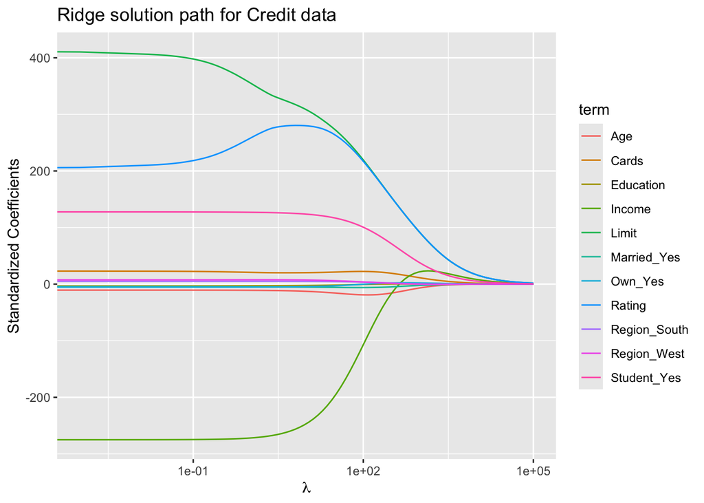

```r
broom:::tidy.glmnet(fit_ridge$fit$fit$fit) %>%
  print(width = Inf) %>%
  filter(term != "(Intercept)") %>%
  ggplot() +
  geom_line(mapping = aes(x = lambda, y = estimate, color = term)) +
  scale_x_log10() +
  labs(
    x = quote(lambda),
    y = "Standardized Coefficients",
    title = "Ridge solution path for Credit data"
  )
```

**Python**

Since scikit-learn only takes arrays $X$ and $y$, we first apply transformers to transform the dataframe `Credit` into arrays.